# inference

## setup

## load packages

```r
## graphics
library(ggplot2)
theme_set(theme_bw()+theme(panel.spacing=grid::unit(0,"lines")))
library(directlabels)
## modeling/coef plots
library(lme4)
library(broom)
library(broom.mixed)
library(dotwhisker)
library(ggstance) ## horizontal geoms
library(stargazer)
## manipulation
library(tidyverse)
```

## coefficient plots

## principles

- make it easy to compare magnitudes
- use appropriate scales
- which comparisons do you want to make?
- typically drop intercept (why?)

## nuts and bolts

- old and busted: `arm::coefplot`, `coefplot2`
- new hotness:
  - `dotwhisker`
  - `broom` + `ggplot2` + `ggstance`

## example

```r
data(Contraception,package="mlmRev")
Contraception <- Contraception %>%
    mutate(ch=factor(livch != 0, labels = c("N", "Y")))
m3 <- glmer(use ~ age * ch + I(age^2) + urban + (1 | urban:district),
            data=Contraception, family=binomial)
```

```r
ss <- stargazer(m3,type="html")
```

## stargazer output

|  | *Dependent variable:* |
| --- | --- |
|  | use |
| age | -0.046** |
|  | (0.022) |
| chY | 1.213*** |
|  | (0.210) |
| I(age2) | -0.006*** |
|  | (0.001) |
| urbanY | 0.787*** |
|  | (0.172) |
| age:chY | 0.066*** |
|  | (0.026) |
| Constant | -1.341*** |
|  | (0.222) |
| Observations | 1,934 |
| Log Likelihood | -1,177.237 |
| Akaike Inf. Crit. | 2,368.475 |
| Bayesian Inf. Crit. | 2,407.446 |
| *Note:* | p<0.1; p<0.05; p<0.01 |

Also see `broom`/`broom.mixed` + `huxtable` packages

## coefficient plot

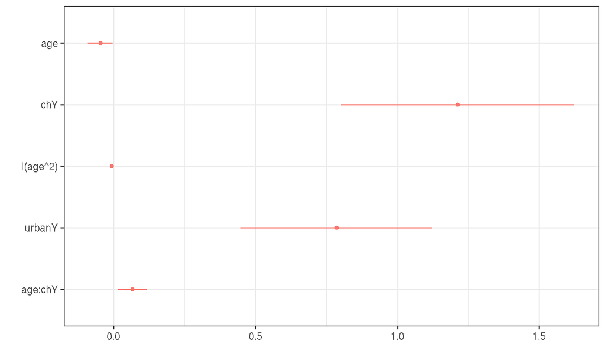

```r
gg0 <- dotwhisker::dwplot(m3)
print(gg0)
```

## add reference line

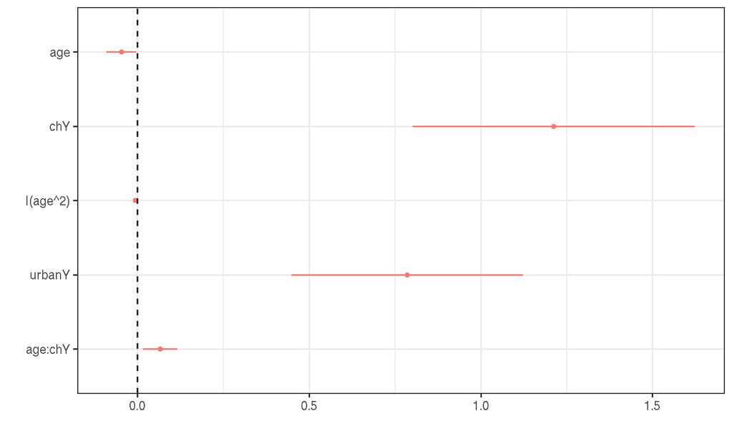

```r
gg1 <- gg0+geom_vline(xintercept=0,lty=2)
print(gg1)
```

## scaling

- need to scale parameters appropriately to compare magnitude
- Gelman (2008); Schielzeth (2010)
- `arm::standardize`, `arm::rescale` (handy but inefficient)

> binary.inputs: options for standardizing binary variables, default is ‘center’; ‘0/1’ keeps original scale; ‘-0.5,0.5’ rescales 0 as -0.5 and 1 as 0.5; ‘center’ subtracts the mean; and ‘full’ subtracts the mean and divides by 2 sd.
- mixed models: standard deviations have same scale as corresponding parameter

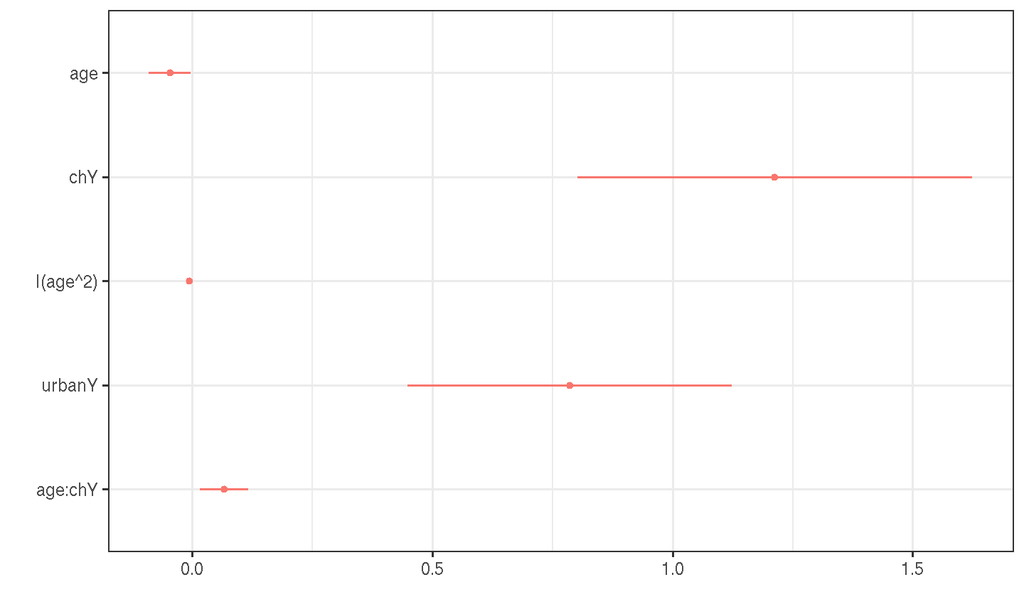

```r
dotwhisker::dwplot(m3,by_2sd=FALSE)
```

## alternative: update with scaled age parameter

```r
Contraception <- Contraception %>%
    mutate(sc_age=drop(scale(age)))
m3_sc <- update(m3,
      . ~ sc_age * ch + I(sc_age^2) + urban + (1 | urban:district))
```

## plot

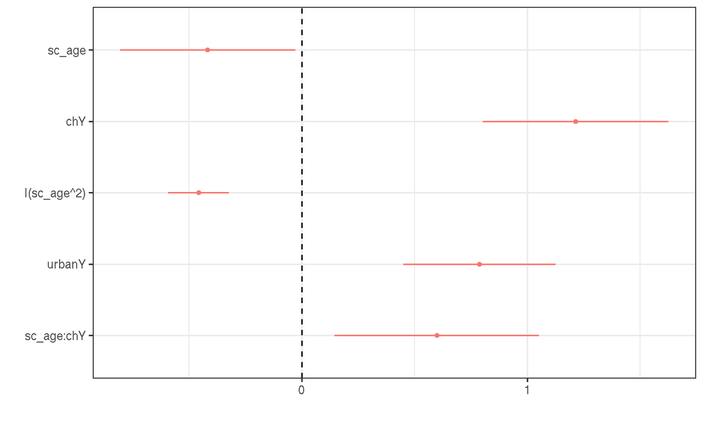

```r
dotwhisker::dwplot(m3_sc,effects="fixed")+
    geom_vline(xintercept=0,lty=2)
```

## manually tidying

```r
cc <- broom.mixed::tidy(m3_sc,effects="fixed")
print(cc,digits=3)
```

```
## # A tibble: 6 x 6
##   effect term        estimate std.error statistic  p.value
##   <chr>  <chr>          <dbl>     <dbl>     <dbl>    <dbl>
## 1 fixed  (Intercept)   -1.34     0.222      -6.04 1.56e- 9
## 2 fixed  sc_age        -0.416    0.198      -2.10 3.57e- 2
## 3 fixed  chY            1.21     0.210       5.79 7.18e- 9
## 4 fixed  I(sc_age^2)   -0.457    0.0690     -6.62 3.51e-11
## 5 fixed  urbanY         0.787    0.172       4.57 4.88e- 6
## 6 fixed  sc_age:chY     0.599    0.231       2.59 9.57e- 3
```

## GLM for comparison

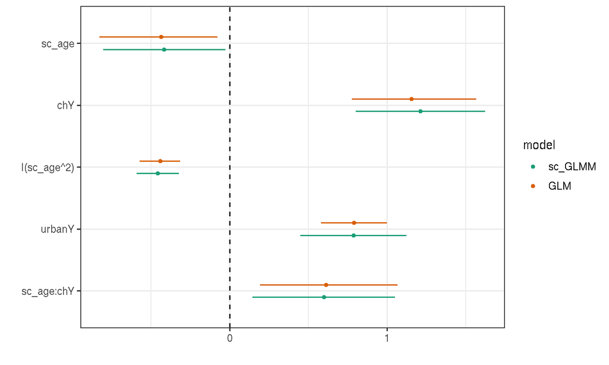

```r
m3_fixed <-  glm(
    use ~ sc_age * ch + I(sc_age^2) + urban,
    data=Contraception, family=binomial)
dotwhisker::dwplot(list(sc_GLMM=m3_sc,GLM=m3_fixed))+
    geom_vline(xintercept=0,lty=2)+ scale_colour_brewer(palette="Dark2")
```

## dotwhisker limitations

- might want to post-process output of `tidy()`

## alternative: data prep

```r
m3_res <- map(list(with_re=m3_sc,no_re=m3_fixed),tidy,
              conf.int=TRUE) %>%
    bind_rows(.id="model") %>%
    mutate(term=factor(term,levels=unique(term))) %>%
    filter(term!="(Intercept)")
```

## alternative: plot

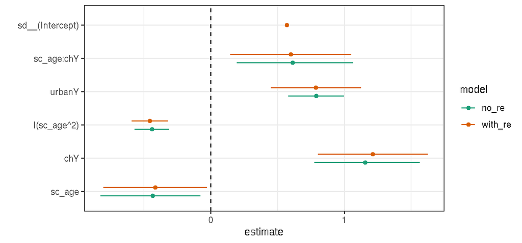

```r
pd <- ggstance::position_dodgev(height=0.5)
(gg5 <- ggplot(m3_res,aes(x=estimate,y=term,colour=model))
    + geom_point(position=pd) + labs(y="")
    + ggstance::geom_linerangeh(aes(xmin=conf.low,xmax=conf.high),
                               position=pd)
    + scale_colour_brewer(palette="Dark2") + geom_vline(xintercept=0,lty=2))
```

## reorder terms

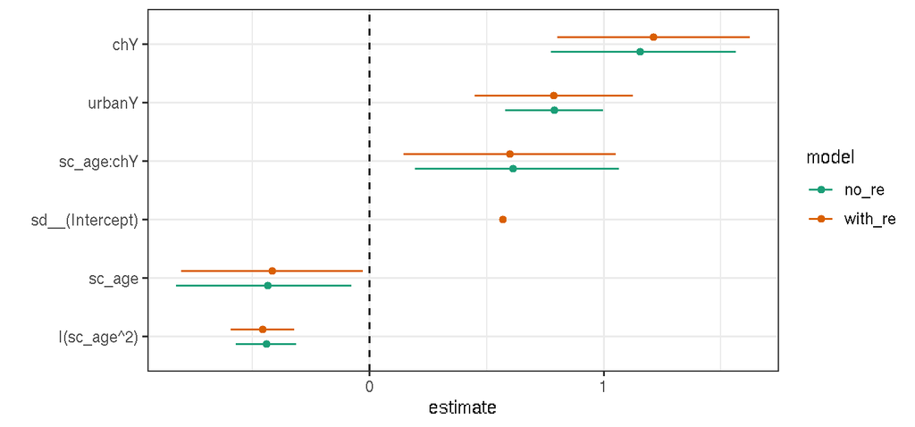

```r
m3_res_order <- mutate(m3_res,term=reorder(term,estimate))
gg5 %+% m3_res_order
```

## other improvements/applications

- useful in comparing lots of models
- models with many parallel parameters
- separate parameter types with facets
- sort by magnitude of estimate

## final thoughts

- can often use a wide aspect ratio (don’t need much height)
- may need to replace/improve coefficient names
- see `broom`, `broom.mixed` for more tidying options

## turning tables into graphs

## why graphs instead of tables?

- Gelman, Pasarica, and Dodhia (2002); Gelman (2011)

> tables are best suited for looking up specific information, and graphs are better for perceiving trends and making comparisons and predictions
- easier to read and compare
- easier to perceive magnitudes
- less prone to dichotomization

## why not tables instead of graphs?

- looking up specific values (dynamic graphs?)
- cultural familiarity
- includes all the information
  - include data separately/machine-readably?

## principles

- use small multiples
- use appropriate scales
- Cleveland hierarchy etc.

## example: Wei (2017) Table 5.5

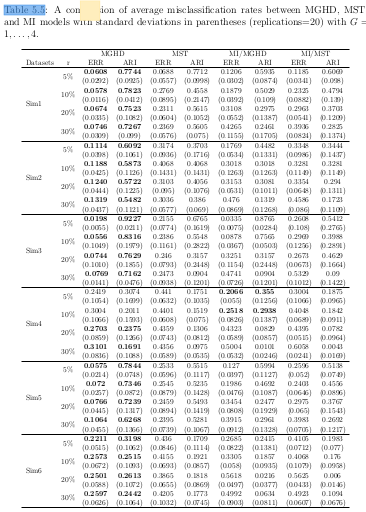

## rearranged data

```r
## need read_table2() for 'irregular' data
dd <- read_table2("data/wei_tab5.5.txt")
head(dd)
```

```
## # A tibble: 6 x 11
##   dataset     r type  MGHD.ERR MGHD.ARI MST.ERR MST.ARI `MI/MGHD.ERR`
##   <chr>   <dbl> <chr>    <dbl>    <dbl>   <dbl>   <dbl>         <dbl>
## 1 sim1     0.05 est     0.0608   0.774   0.0688  0.771         0.121
## 2 sim1     0.05 sd      0.0292   0.0925  0.0557  0.0998        0.0302
## 3 sim1     0.1  est     0.0578   0.782   0.277   0.456         0.188
## 4 sim1     0.1  sd      0.0116   0.0412  0.0895  0.215         0.0392
## 5 sim1     0.2  est     0.0674   0.752   0.231   0.562         0.311
## 6 sim1     0.2  sd      0.0335   0.108   0.0604  0.105         0.0552
## # … with 3 more variables: MI/MGHD.ARI <dbl>, MI/MST.ERR <dbl>,
## #   MI/MST.ARI <dbl>
```

## rearrange

```r
dd2 <- (dd
    %>% gather(key=model,value=val,-c(dataset,r,type))
    %>% separate(model,into=c("model","stat"),sep="\\.")
    %>% spread(key=type,value=val) ## est + sd in a single row
)
head(dd2)
```

```
## # A tibble: 6 x 6
##   dataset     r model   stat     est     sd
##   <chr>   <dbl> <chr>   <chr>  <dbl>  <dbl>
## 1 sim1     0.05 MGHD    ARI   0.774  0.0925
## 2 sim1     0.05 MGHD    ERR   0.0608 0.0292
## 3 sim1     0.05 MI/MGHD ARI   0.594  0.0874
## 4 sim1     0.05 MI/MGHD ERR   0.121  0.0302
## 5 sim1     0.05 MI/MST  ARI   0.607  0.098
## 6 sim1     0.05 MI/MST  ERR   0.118  0.0341
```

```r
simtab <- read.table(header=TRUE,text="
dataset distribution covstruc separation
sim1 MGHD VEE well-separated
sim2 MGHD VEE overlapping
sim3 MST VEI well-separated
sim4 MST VEI overlapping
sim5 GMM VEE well-separated
sim6 GMM VEE overlapping
")
dd3 <- dd2 %>% merge(simtab,by="dataset")
```

## code

```r
gg1 <- (ggplot(dd3,aes(factor(r),est,colour=model))
    + geom_point()+geom_line(aes(group=model))   ## points and lines
    ## transparent ribbons, +/- 1 SD:
    + geom_ribbon(aes(ymin=est-sd,ymax=est+sd,group=model,fill=model),
                colour=NA,alpha=0.3)
    + scale_y_continuous(limits=c(0,1),oob=scales::squish)
    + facet_grid(stat~distribution+covstruc+separation)
    + labs(x="r (proportion missing)",y="")
    + scale_colour_brewer(palette="Dark2") + scale_fill_brewer(palette="Dark2"))
```

[figure not shown]

## possible improvements?

- order models
- colour panel backgrounds according to whether well-separated or not (`geom_rect`)
- direct labeling (only in rightmost facets?)
- could collapse sim labels
- change x-axis to continuous?
- invert ARI or ERR so rankings are the same?

## other hints

- `tabulizer` package
- use `merge()` or tidyverse `*_join()` (e.g. `full_join`) to combine information

```r
nm <- (read_csv(fn,skip=skip,n_max=n_header,col_names=FALSE)
  %>% t()            ## transpose
  %>% as_tibble()
  %>% mutate_all(zoo::na.locf)
  %>% apply(MARGIN=1,paste,collapse="_")
)
main <- (read_csv(fn,skip=skip+n_header,
                  n_max=n_table,
                  col_names=FALSE, ...)
  %>% setNames(nm)
)
pivot_longer(...) ## automatically separates according to pattern
```

## references

Gelman, Andrew. 2008. “Scaling Regression Inputs by Dividing by Two Standard Deviations.” *Statistics in Medicine* 27 (15): 2865–73. https://doi.org/10.1002/sim.3107.

———. 2011. “Why Tables Are Really Much Better Than Graphs.” *Journal of Computational and Graphical Statistics* 20 (1): 3–7. https://doi.org/10.1198/jcgs.2011.09166.

Gelman, Andrew, Cristian Pasarica, and Rahul Dodhia. 2002. “Let’s Practice What We Preach: Turning Tables into Graphs.” *The American Statistician* 56 (2): 121–30. http://www.tandfonline.com/doi/abs/10.1198/000313002317572790.

Schielzeth, Holger. 2010. “Simple Means to Improve the Interpretability of Regression Coefficients.” *Methods in Ecology and Evolution* 1: 103–13. https://doi.org/10.1111/j.2041-210X.2010.00012.x.

Wei, Yuhong. 2017. “Extending Growth Mixture Models and Handling Missing Values via Mixtures of Non-Elliptical Distributions.” Thesis. https://macsphere.mcmaster.ca/handle/11375/21987.